# Price vs. (intrinsic) value of a stock

- The **price** of a stock is the amount of money we pay when we buy one unit of the stock or we receive when we sell one unit of stock.
- The **value** of a stock is how much the stock is worth (recall the formula for calculating the intrinsic value you learned in financial management course).
- The price of a stock is often roughly the same for buyers who want to buy and sellers who want to sell if the stock is heavily traded.
- But value of a stock may be different to different investors. This is why there are trades in the stock market.
- An investor buys a stock when she thinks it is undervalued and sells it when she thinks it is overvalued.
- Data of a stock’s price is the core component of equity (fundamental and technical) analysis.

# Import stock price data

- We first learn how to obtain and analyze raw stock price data (section 2.1).
- Then we learn the techniques that help us to manipulate raw stock price data (clean the data) to fit some basic analysis (section 2.2 and 2.3).
- A stock’s price data can be downloaded from some websites, for example, Yahoo Finance.
- Two ways to download them:
1. Download the data **directly** with **“csv”** file from the website.
2. Use a specific `R` **function**, such as `getSymbols` from package `quantmod` (convenient but may not be reliable, so will not be used).

# Check the ticker symbol before you download the stock data

- Be careful about the ticker symbol you use.
- Sometimes you think the ticker symbol is for the stock you want to analyze, but actually it is not.
- For example, in Yahoo Finance:
  1. Hewlett-Packard’s: `HPQ` not `HP`.
  2. Taiwan Semiconductor Manufacturing Company Limited: `TSM` not `TSMC`
  3. S&P500 index: `^GSPC` not `SPX`
  4. Dow Jones Industrial Average: `^DJI` not `DJIA`
  5. NASDAQ: `^IXIC` not `NAS`
- Notice that some of the data can not be downloaded (e.g., S&P500 and Dow Jones)

# Step 1: Download data directly from Yahoo Finance

- Download stock price data of Amazon (ticker: **AMZN**) from Yahoo Finance (https://finance.yahoo.com).
- Be careful to specify **frequency** and **date** of the data you want to download, for example,
1. Frequency: daily
2. Date: Dec-31-2010 ~ Dec-31-2013
- The data is a **“csv”** file.
- Be careful about NA (data **not available**) or other annoying features of the data (we will discuss the issue later).

# Step 2: Import data into R

- Clear the consol (very important when beginning a new project)

```r
rm(list = ls(all = TRUE))
```

- Use `read.table` or `read.csv` function

```r
data_AMZN<-read.table("C:/Users/yyu_m/Desktop/Financial_Data_Analysis_2024/data/AMZN.csv", header= T, sep=",")
```

- Check **class** of the data

```r
class(data_AMZN)
```

```
## [1] "data.frame"
```

- Check how many observations (rows) and how many variables (columns) in the data. Use the function `dim`:

```r
dim(data_AMZN)
```

```
## [1] 755   7
```

- Use `head` and `tail` to look at the first and last few observations (rows).

```r
head(data_AMZN)
```

```
##         Date   Open   High    Low  Close Adj.Close  Volume
## 1 2010/12/31 181.96 182.30 179.51 180.00    180.00 3451900
## 2   2011/1/3 181.37 186.00 181.21 184.22    184.22 5331400
## 3   2011/1/4 186.15 187.70 183.78 185.01    185.01 5031800
## 4   2011/1/5 184.10 187.45 184.07 187.42    187.42 3418800
## 5   2011/1/6 186.50 187.41 185.25 185.86    185.86 3179700
## 6   2011/1/7 187.88 188.45 183.74 185.49    185.49 5221700
```

```r
tail(data_AMZN)
```

```
##           Date   Open   High    Low  Close Adj.Close  Volume
## 750 2013/12/23 403.69 405.00 399.20 402.92    402.92 2659500
## 751 2013/12/24 402.52 403.72 396.37 399.20    399.20 1380400
## 752 2013/12/26 401.79 404.52 396.81 404.39    404.39 1868500
## 753 2013/12/27 404.65 405.63 396.25 398.08    398.08 1986900
## 754 2013/12/30 399.41 399.92 392.45 393.37    393.37 2487100
## 755 2013/12/31 394.58 398.83 393.80 398.79    398.79 1996500
```

- `Adj.Close` is **adjusted close price**, which is the close price of the stock after taking dividends and stock splits into account.

# Step 3: Check data: Convert the ‘date’ variable from character to date

- To know what columns the data has, we can directly look at the data by using the functions `head` or `tail` mentioned before.
- Or we can use the function `names` or `colnames`.

```r
names(data_AMZN)
```

```
## [1] "Date"      "Open"      "High"      "Low"       "Close"     "Adj.Close"
## [7] "Volume"
```

```r
colnames(data_AMZN)
```

```
## [1] "Date"      "Open"      "High"      "Low"       "Close"     "Adj.Close"
## [7] "Volume"
```

- It is important to know which class the data (the column or row of the data) belongs to before doing data analysis in `R`.
- Sometimes transforming data to a suitable class is necessary. But what class is suitable is case by case.
- Look at the column of `Date` in the data by using `data_AMZN$Date`.
- Check class of the column of `Date`

```r
class(data_AMZN$Date)
```

```
## [1] "character"
```

- Convert **character** to **date**

```r
data_AMZN$Date<-as.Date(data_AMZN$Date, format = "%Y/%m/%d")
class(data_AMZN$Date)
```

```
## [1] "Date"
```

- `format` should match **the format of Date shown in your file**.

# Step 4: Sort data into chronological order

- Also be careful if you save the Yahoo Finance data into **csv** file by using Excel.
- For example, in rare situations, data might appear in “reverse” chronological order.
- To solve this, use

```r
data_AMZN<-data_AMZN[order(data_AMZN$Date), ]
```

- But before using the function `order`, be careful about class of the column of `Date` (It should be `Date` class).

# Step 5: Convert from a `data.frame` object to a `xts` object

- Use the function `xts` in package `xts`.
- The data’s class will become different from `data.frame`.

```r
library(xts)
xts_AMZN<-xts(data_AMZN[, 2:7], order.by = data_AMZN$Date)
class(xts_AMZN)
```

```
## [1] "xts" "zoo"
```

- Have a look of the trandformed data:

```r
head(xts_AMZN)
```

```
##              Open   High    Low  Close Adj.Close  Volume
## 2010-12-31 181.96 182.30 179.51 180.00    180.00 3451900
## 2011-01-03 181.37 186.00 181.21 184.22    184.22 5331400
## 2011-01-04 186.15 187.70 183.78 185.01    185.01 5031800
## 2011-01-05 184.10 187.45 184.07 187.42    187.42 3418800
## 2011-01-06 186.50 187.41 185.25 185.86    185.86 3179700
## 2011-01-07 187.88 188.45 183.74 185.49    185.49 5221700
```

```r
tail(xts_AMZN)
```

```
##              Open   High    Low  Close Adj.Close  Volume
## 2013-12-23 403.69 405.00 399.20 402.92    402.92 2659500
## 2013-12-24 402.52 403.72 396.37 399.20    399.20 1380400
## 2013-12-26 401.79 404.52 396.81 404.39    404.39 1868500
## 2013-12-27 404.65 405.63 396.25 398.08    398.08 1986900
## 2013-12-30 399.41 399.92 392.45 393.37    393.37 2487100
## 2013-12-31 394.58 398.83 393.80 398.79    398.79 1996500
```

- Transforming data to `xts` class is useful when we want to use some functions, for example `chartSeries` in `quantmod` for candlestick plot:

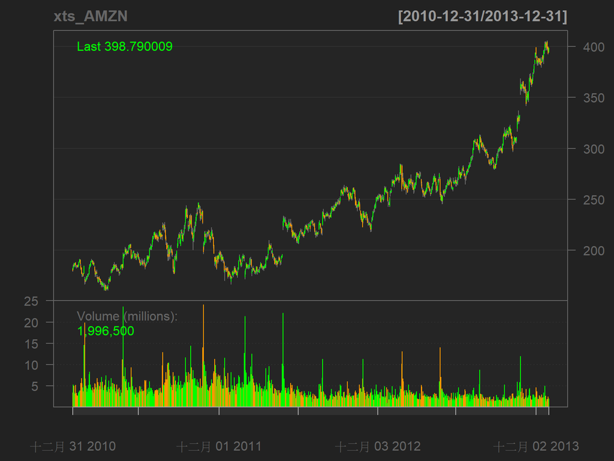

```r
library(quantmod)
chartSeries(xts_AMZN)
```

# Step 6: Rename the variables

- Again to look at names of the variables in the xts object, use `name(xts_AMZN)` or `colnames(xts_AMZN)`:

```r
names(xts_AMZN)
```

```
## [1] "Open"      "High"      "Low"       "Close"     "Adj.Close" "Volume"
```

```r
colnames(xts_AMZN)
```

```
## [1] "Open"      "High"      "Low"       "Close"     "Adj.Close" "Volume"
```

- We can change names of the variables by using

```r
names(xts_AMZN)<-c("AMZN.Open","AMZN.High","AMZN.Low","AMZN.Close","AMZN.Adjusted","AMZN.Volume")
head(xts_AMZN)
```

```
##            AMZN.Open AMZN.High AMZN.Low AMZN.Close AMZN.Adjusted AMZN.Volume
## 2010-12-31    181.96    182.30   179.51     180.00        180.00     3451900
## 2011-01-03    181.37    186.00   181.21     184.22        184.22     5331400
## 2011-01-04    186.15    187.70   183.78     185.01        185.01     5031800
## 2011-01-05    184.10    187.45   184.07     187.42        187.42     3418800
## 2011-01-06    186.50    187.41   185.25     185.86        185.86     3179700
## 2011-01-07    187.88    188.45   183.74     185.49        185.49     5221700
```